# Data Manipulation

|  | id | author_id | project_id | commit_created_at | language | projects_created_at | language_code |
| --- | --- | --- | --- | --- | --- | --- | --- |
| 1 | 8089 | 1804 | 236 | 2012-08-01 20:34:05 | c | 2012-07-25 18:41:03 | 1 |
| 2 | 8092 | 1804 | 236 | 2012-08-01 19:01:32 | c | 2012-07-25 18:41:03 | 1 |
| 3 | 8097 | 1783 | 236 | 2012-08-01 19:46:36 | c | 2012-07-25 18:41:03 | 1 |
| 4 | 123244 | 1783 | 236 | 2012-08-02 20:42:45 | c | 2012-07-25 18:41:03 | 1 |
| 5 | 123249 | 1804 | 236 | 2012-08-02 22:32:53 | c | 2012-07-25 18:41:03 | 1 |
| 6 | 766342 | 60012 | 236 | 2012-08-04 14:08:26 | c | 2012-07-25 18:41:03 | 1 |

```r
n_projects <- length(unique(df_commits$project_id))
n_committers <- length(unique(df_commits$author_id))
```

There are a total of 316798 projects, and 394449 users have contributed to such projects.

# Users

We define productivity of a user as the total number of commits that a person has made since they joined Github. Here we focus on the subsample of users who have made at least one commit.

- The top 20% most productive users (i.e. with at least 26 commits) contribute to nearly 87.7% of the total commits.
- The top 10% most productive users (i.e. with at least 65 commits) contribute to nearly 77.1% of the total commits.
- The top 5% most productive users (i.e. with at least 141 commits) contribute to nearly 64.8% of the total commits.
- The top 1% most productive users (i.e. with at least 574 commits) contribute to nearly 37.5% of the total commits.

# Projects

```r
commits_project <- df_commits %>%
                   group_by(project_id) %>%
                   summarise(total_commits = n())

var_10 <- round(ecdf(commits_project$total_commits)(10) * 100, 1)
var_100 <- 100 - round(ecdf(commits_project$total_commits)(100) * 100, 1)
```

- 55% of the projects have at most 10 commits.
- 7.8% of the projects have at least 100 commits.

Is it true that more productive users, i.e. users that have a higher number of commits, are also involved in more projects?

```r
df <- df_commits %>%
        group_by(author_id) %>%
        summarise(total_commit = n(), n_projects = n_distinct(project_id))

thresholds <- c(0,25,50,75,100,250,500,20000)
store <- matrix(0,2,length(thresholds)-1)

for (i in 1:(length(thresholds)-1)){
  store[,i] <- as.numeric(filter(df,total_commit >=thresholds[i] & total_commit < thresholds[i+1])
                          %>% summarise(mean(n_projects),n()))
}

colnames(store) <- c('<25','[25,50)','[50,75)','[75,100)','[100,250)','[250,500)','500+')
rownames(store) <- c('Avg. Number of Project','N. Authors')
write.csv(store,'C:/Users/mmore/Dropbox/GitHub/Output/table_1.csv')
print(store)
```

```
##                                 <25     [25,50)      [50,75)    [75,100)
## Avg. Number of Project 1.230959e+00     2.03691     2.484638    2.890749
## N. Authors             3.113240e+05 33568.00000 14093.000000 8064.000000
##                           [100,250)   [250,500)        500+
## Avg. Number of Project     3.749924    5.469236    9.554641
## N. Authors             16475.000000 6176.000000 4740.000000
```

```r
rm(df)
```

# Time Trends in Total Number of Commits

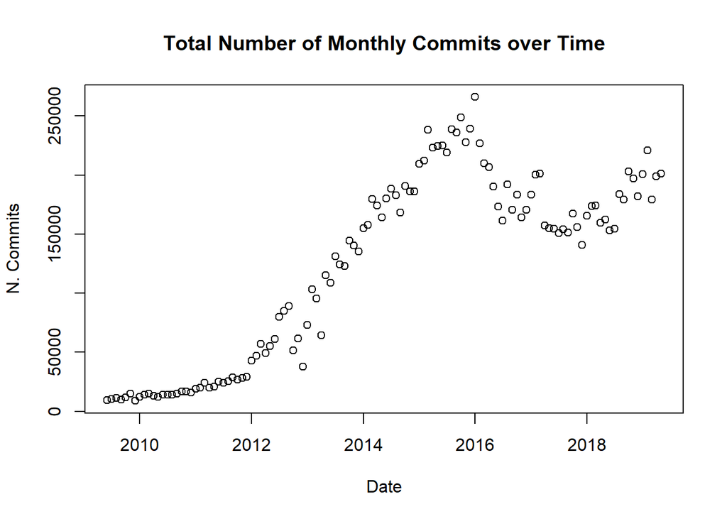

```r
#plot_commits('C')
#plot_commits('python')
#plot_commits('javascript')
#plot_commits('php')
#plot_commits('java')
#plot_commits('chash')
```

# Time Trends in Number of Active Projects

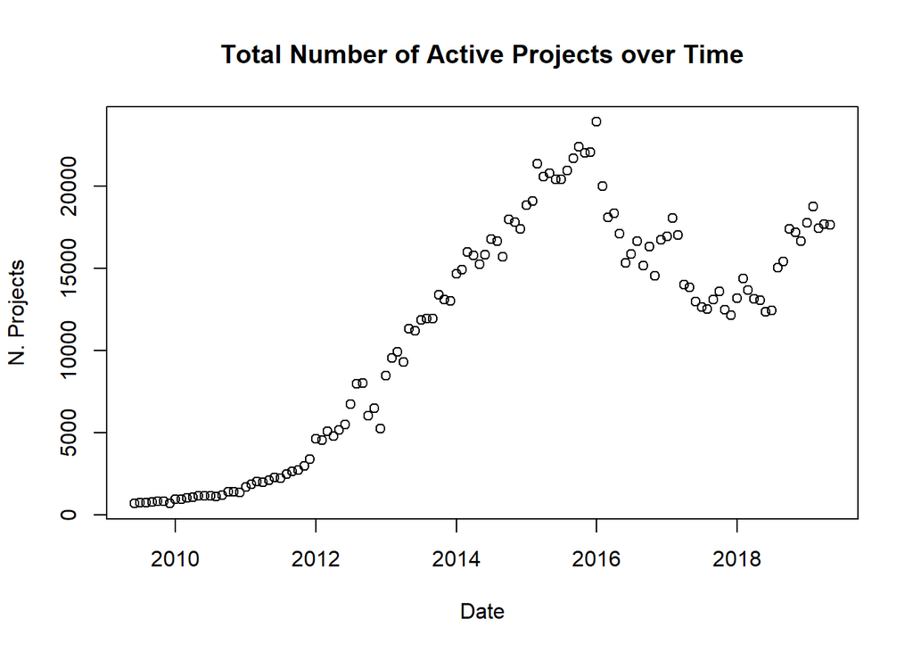

# Productive Users

Vasilescu uses as a way to measure *productive* users the following metrics:

1. at least 500 commits to at least 10 non-forked repositories
2. at least 5 years between their first and last commit

They identify approximately 1300 users that fall in the category of *productive* users. They solve the problem of aliases, i.e. users who that commit to projects under different names. Vasilescu through some heuristics estimates that approximately 30% of users have multiples alises.

# Filter used to classify higly productive users

There are a total number of 27197 users who:

- are active for at least 1 years
- have contributed to at least 2 projects
- have made at least 50 commits

# Variable Description

- *author_id*: user identifier
- *month*: period of reference
- *monthly_commits*: total number of commits made in a month
- *monthly_project*: number of different project a user commited in a month
- *first_commit*: month in which user made the first recorded commit
- *last_commit*: month in which user made the last recorded commit
- *total_commits*: total number of commits made by a user over time
- *number_project*: total number of projects an user made contribution to
- *time active*: number of days between first and last commit
- *n_languages*: number of languages an author has committed in hist life

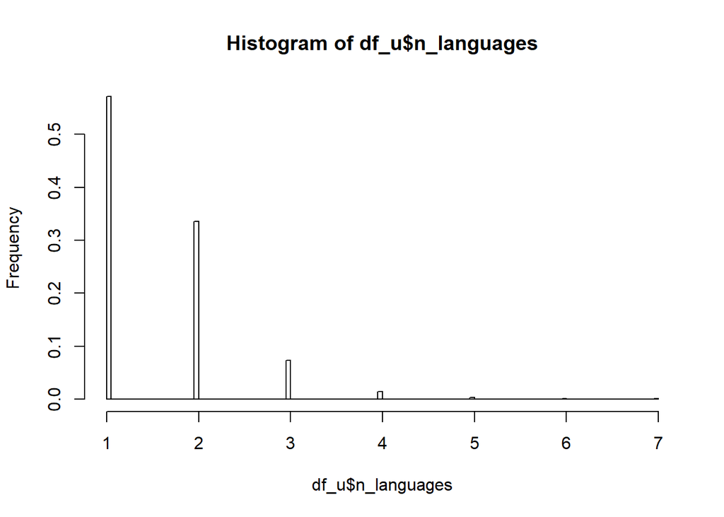

```r
h <- hist(df_u$n_languages, breaks = 100, plot=FALSE,title='N. Languages')
h$counts=h$counts/sum(h$counts)
plot(h)
```

# Projects Life-Cycle

```
##              N. Projects Mean Total Commits Max Total Commits
## 1 month           166340           8.862408              3294
## 2-3 months         25618          26.636857              4636
## 4-6 months         20675          34.111197              2281
## 7-12 months        25322          44.983730              4530
## 13-36 months       45445          77.891187             11881
## 36+ months         28771         249.997845             64542
##              Median Total Commits Mean N. Authors Max N. Authors
## 1 month                         4        1.199874             32
## 2-3 months                     13        1.547974             44
## 4-6 months                     15        1.678742             95
## 7-12 months                    18        1.930969            265
## 13-36 months                   27        2.679393            582
## 36+ months                     62        6.738487           1402
##              Median N. Authors
## 1 month                      1
## 2-3 months                   1
## 4-6 months                   1
## 7-12 months                  1
## 13-36 months                 2
## 36+ months                   3
```

#New Projects

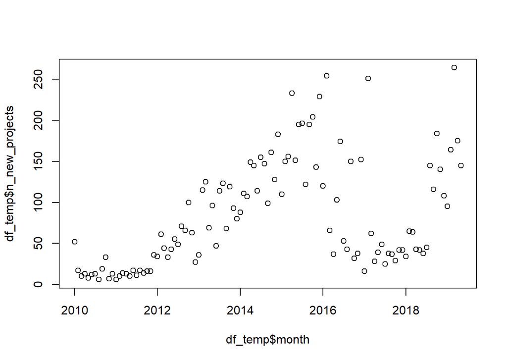

```r
df_temp <- df %>%
           group_by(month) %>%
           filter(project_age==0) %>%
           summarise(n_new_projects=n()) %>%
           filter(month>=start_date,month<=end_date)


plot(df_temp$month,df_temp$n_new_projects)
```

```
## [1] 180534
```

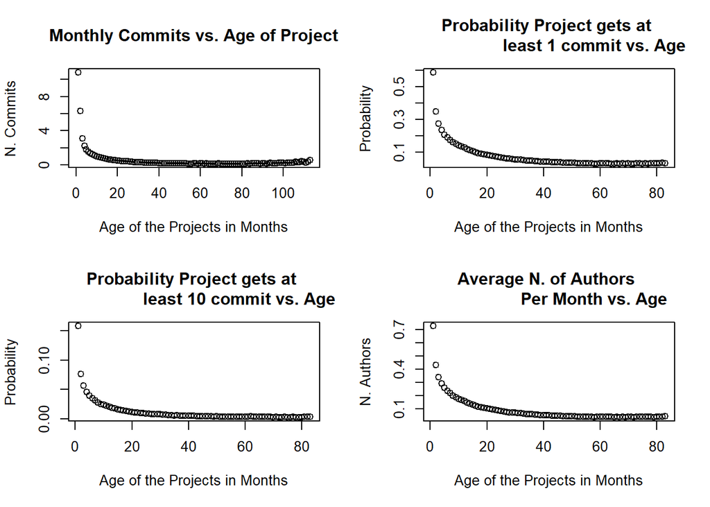

```r
new_plot <- function(df,lb,ub){

        df_temp <- df %>%
                   group_by(project_id) %>%
                   filter(sum(n_commits)>=lb,sum(n_commits)<=ub)

        print(length(unique(df_temp$project_id)))

        df_temp <- df_temp %>%
                   group_by(project_age) %>%
                   summarise(n=mean(n_commits),
                             p=mean(as.numeric(n_commits>0)),
                             p10=mean(as.numeric(n_commits>10)),
                             mean_authors=mean(monthly_n_authors))
        par(mfrow=c(2,2))

        plot(df_temp$n,
             xlab='Age of the Projects in Months',
             ylab='N. Commits',
             main='Monthly Commits vs. Age of Project')

        plot(df_temp$p[2:84],
             xlab='Age of the Projects in Months',
             ylab='Probability',
             main='Probability Project gets at
                   least 1 commit vs. Age')

        plot(df_temp$p10[2:84],
             xlab='Age of the Projects in Months',
             ylab='Probability',
             main='Probability Project gets at
                   least 10 commit vs. Age')

        plot(df_temp$mean_authors[2:84],
             xlab='Age of the Projects in Months',
             ylab='N. Authors',
             main='Average N. of Authors
                   Per Month vs. Age')



        return()
}

new_plot(df,1,500)
```

```
## [1] 3375
```

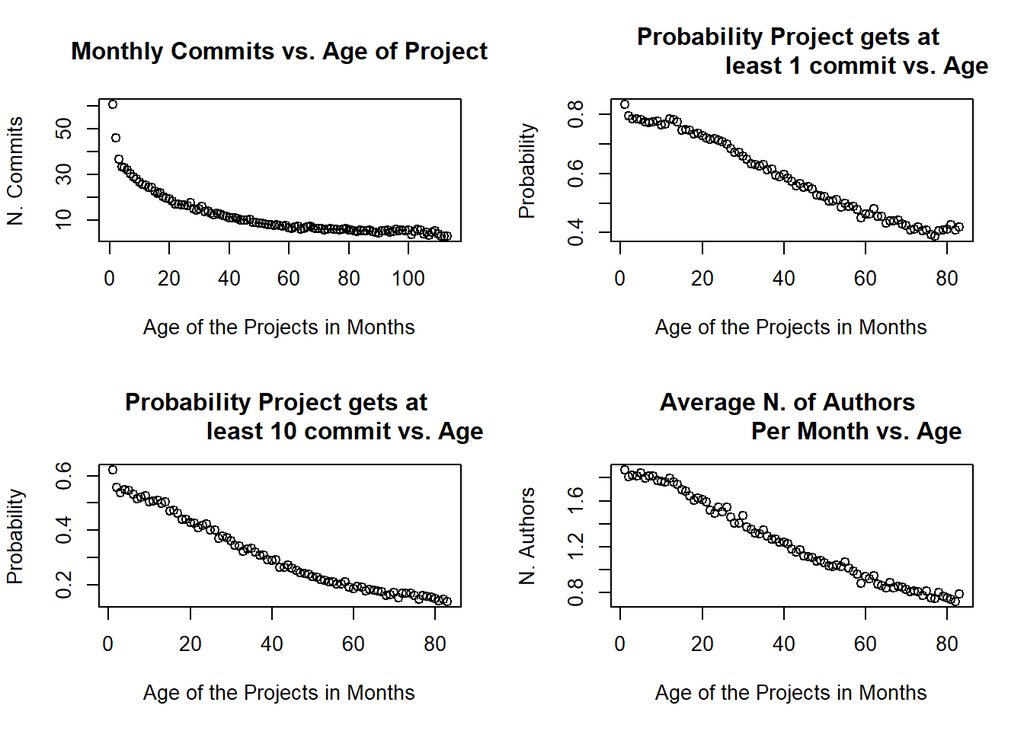

```r
new_plot(df,501,2500)
```

```
## [1] 459
```

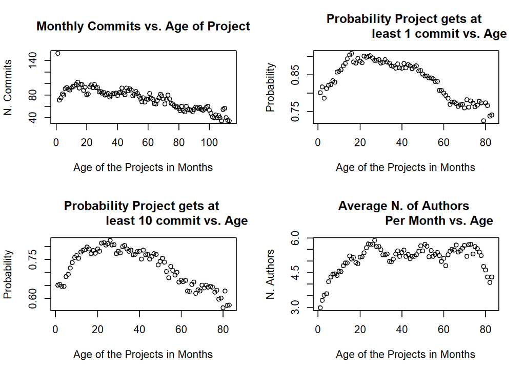

```r
new_plot(df,2501,100000)
```

#Users Life-Cycle

Here we want to investigate some statistics about the contribution history of users during their life on GitHub.

First of all, we need to create a measure of users age within the GitHub platform. We set a user to have age 0 to the month in which the user makes the first commit. The question here is the following: how do users behave over their life on Github? Do they contribute greatly to a project, and then stop contributing? Or do they contribute to multiple projects over their lite time? In other words, are users very intensive in the contribution, or do they smooth it out during their life-time.

In order to answer these questions, I compute for each users, the share of commits that that user has made in his/her most productive month over the total number of commits that person has made in her life-time on Github. From the histogram below, we see that a significant number of users contribute to at least 95% of the total number of commits they make in a month. As expected, there is a negative correlation between the share of the maximum number of commits in a month (measure of intensity of contribution) and the total number of commits made (measure of overall productivity). In order to avoid capturing users who are in early stages of their life-cycle on GitHub, we make eliminate users who have enter Github (by committing) later than January 2018.

The results presented below suggest that there is a significant presence of users who contribute intensively, in the sense that the month in which they committed the most corresponds to most of the activity they perform over their entire life on Github.

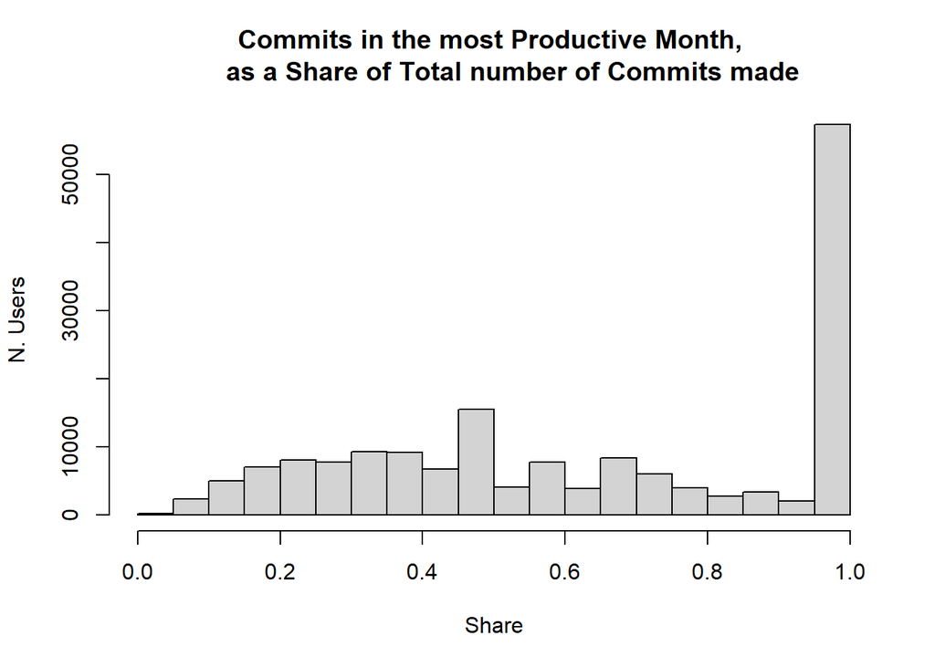

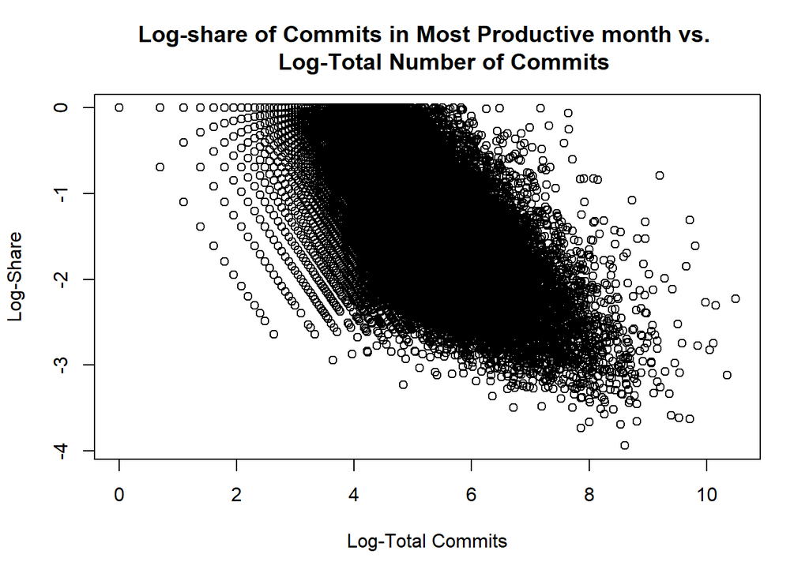

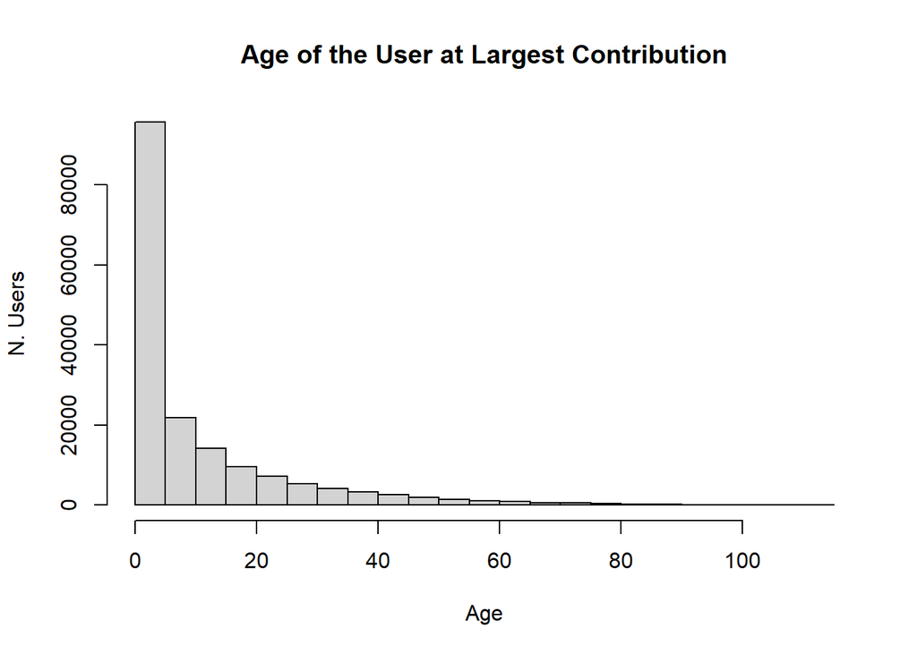

```r
df_temp <- df %>%
           group_by(author_id) %>%
           filter(total_commits>=filter_productivity_commits_min,total_commits<filter_productivity_commits_max) %>%
           filter(n_commits>0) %>%
           summarize(period_active=n(),total_commits=sum(n_commits),n_projects=max(n_projects))


store <- matrix(0,6,6)
store[1,1:4] <- as.numeric(df_temp %>% filter(period_active<=1) %>% summarise(average_total_commits=mean(total_commits),n_obs=n(),total_commits=sum(total_commits),average_projects=mean(n_projects)))

store[2,1:4] <- as.numeric(df_temp %>% filter(period_active>1,period_active<=3) %>% summarise(average_total_commits=mean(total_commits),n_obs=n(),total_commits=sum(total_commits),average_projects=mean(n_projects)))

store[3,1:4] <- as.numeric(df_temp %>% filter(period_active>3,period_active<=6) %>% summarise(average_total_commits=mean(total_commits),n_obs=n(),total_commits=sum(total_commits),average_projects=mean(n_projects)))


store[4,1:4] <- as.numeric(df_temp %>% filter(period_active>6,period_active<=12) %>% summarise(average_total_commits=mean(total_commits),n_obs=n(),total_commits=sum(total_commits),average_projects=mean(n_projects)))

store[5,1:4] <- as.numeric(df_temp %>% filter(period_active>12,period_active<=36) %>% summarise(average_total_commits=mean(total_commits),n_obs=n(),total_commits=sum(total_commits),average_projects=mean(n_projects)))

store[6,1:4] <- as.numeric(df_temp %>% filter(period_active>36) %>% summarise(average_total_commits=mean(total_commits),n_obs=n(),total_commits=sum(total_commits),average_projects=mean(n_projects)))

store[,5] <- store[,3] / sum(store[,3])
store[,6] <- store[,2] / sum(store[,2])
colnames(store) <- c('Average Tot. Commits', 'N. Users','Total Number of Commits','Average N. Of Projects','Share of Total Commits','Share of Total Users')
rownames(store) <- c('1 month','2-3 months', '4-6 months', '7-12 months', '13-36 months', '36+ months')

print(round(store,3))
```

```
##              Average Tot. Commits N. Users Total Number of Commits
## 1 month                     4.626    56481                  261287
## 2-3 months                 14.296    45068                  644287
## 4-6 months                 33.558    26691                  895692
## 7-12 months                73.395    20473                 1502617
## 13-36 months              233.159    18354                 4279404
## 36+ months               1077.629     3889                 4190900
##              Average N. Of Projects Share of Total Commits Share of Total Users
## 1 month                       1.321                  0.022                0.330
## 2-3 months                    1.723                  0.055                0.264
## 4-6 months                    2.213                  0.076                0.156
## 7-12 months                   2.917                  0.128                0.120
## 13-36 months                  4.730                  0.363                0.107
## 36+ months                    9.827                  0.356                0.023
```

Here try to understand if there is any observable pattern in the life-cycle of users.

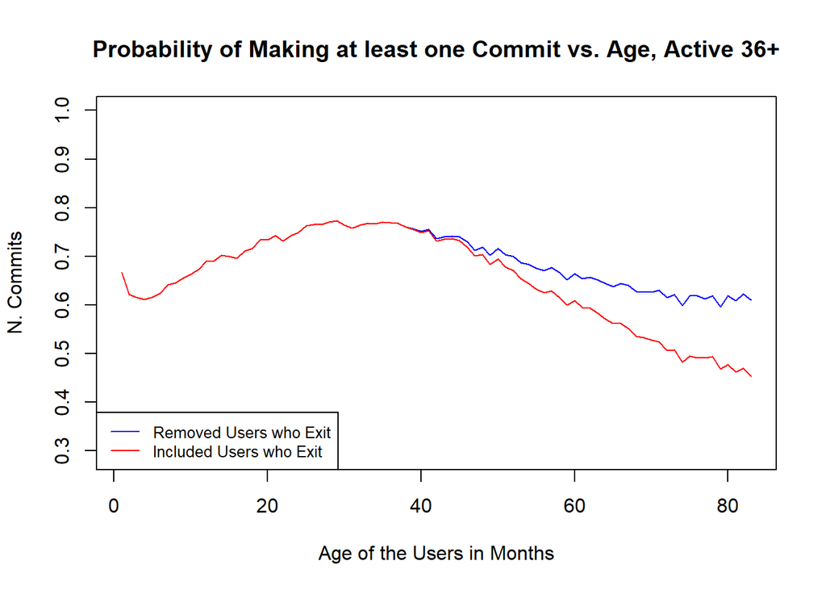

```r
plot_life_profile <-function(lb,ub,title){
    df_temp <- df %>%
               group_by(author_id) %>%
               mutate(active=as.numeric(n_commits>0)) %>%
               filter(sum(active)>=lb,sum(active)<=ub)%>%
               filter(author_age<=author_life) %>%
               group_by(author_age) %>%
               summarise(n=mean(n_commits),p=mean(active))

    df_temp_1 <- df %>%
               group_by(author_id) %>%
               mutate(active=as.numeric(n_commits>0)) %>%
               filter(sum(active)>=lb,sum(active)<=ub)%>%
    #           filter(author_age<=author_life) %>%
               group_by(author_age) %>%
               summarise(n=mean(n_commits),p=mean(active))

    plot(df_temp$p[2:84],
         xlab='Age of the Users in Months',
         ylab='N. Commits',
         main=title,
         ylim=c(min(df_temp_1$p),max(df_temp$p)),
         type = "l",
         lty = 1,
         col = 'blue')

    lines(df_temp_1$p[2:84],col='red')
    legend("bottomleft", legend = c("Removed Users who Exit", "Included Users who Exit"),
           col = c("blue", "red"), lty = c(1,1), cex = 0.8)

    return()


}

plot_life_profile(37,200,'Probability of Making at least one Commit vs. Age, Active 36+')
```

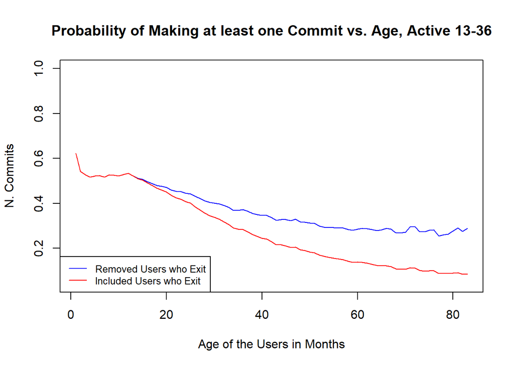

```r
plot_life_profile(13,36,'Probability of Making at least one Commit vs. Age, Active 13-36')
```

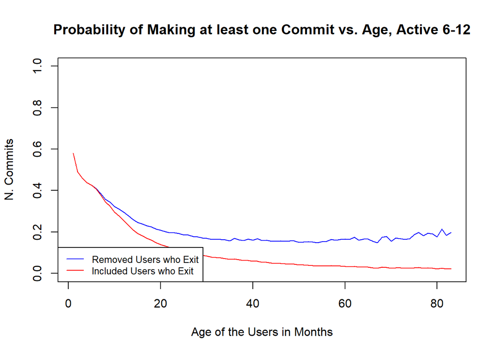

```r
plot_life_profile(6,12,'Probability of Making at least one Commit vs. Age, Active 6-12')
```